# R/simcross User Guide

[figure not shown]

[R/simcross](https://kbroman.org/simcross/) is an [R](https://www.r-project.org) package to simulate genotypes from an experimental cross. The aim is flexibility rather than speed.

Meiosis is simulated following the Stahl model (Copenhaver et al. 2002) with the interference parameter being an integer. In this model, chiasma locations are the superposition of two processes: a proportion *p* come from a process exhibiting no interference (that is, a Poisson process) and the remainder (proportion 1 – *p*) come from a process following the chi-square model (Foss et al. 1993; Zhao et al. 1995). Thus, with *p*=0, the model reduces to the chi-square model. The chi-square model has a single parameter, *m*, which is a non-negative integer and controls the strength of interference. *m*=0 corresponds to no interference. [Broman et al. (2002)](https://pubmed.ncbi.nlm.nih.gov/11901128/) estimated *m*=10 for the level of interference in the mouse (derived assuming *p*=0). The chi-square model is a special case of the gamma model (McPeek and Speed 1995) which has a positive parameter *ν*; the chi-square model corresponds to the case that *m* = *ν* – 1 is an integer.

In many organisms, there is always at least one chiasma for each pair of homologous chromosomes at meiosis. Simulations with [R/simcross](https://kbroman.org/simcross/) may be performed with this assumption; the same model is used, but with rejection sampling to get results conditional on there being at least one chiasma. Note that this isn’t an assumption of an obligate *crossover*; if there is exactly one chiasma, then a random meiotic product will have 0 or 1 crossovers, with probability 1/2 each. Also note that, with the obligate chiasma assumption, chromosomes must be greater than 50 cM.

## Basic functions

There are two basic functions for simulating a cross: `create_parent` and `cross`.

`create_parent` is for generating a parent object, either an inbred individual or the F<sub>1</sub> offspring of two inbred individuals. It takes two arguments: the length of the chromosome in cM, and the allele or pair of alleles.

Here’s how to generate two inbred individuals, one from each of strain 1 and strain 2, and an F<sub>1</sub> individual, with a 100 cM chromosome.

```r
library(simcross)
p1 <- create_parent(L=100, allele=1)
p2 <- create_parent(L=100, allele=2)
f1 <- create_parent(L=100, allele=1:2)
```

You don’t need to specify the arguments by name (e.g., in the last line above, you could just write `create_parent(100, 1:2)`); I’m doing so here just to better document the names of the arguments.

The `cross` function is used to generate one offspring from the cross between two individuals. The input is a pair of individuals (e.g., as produced by `create_parent`), the interference parameter `m` (default `m=10`), the parameter `p` for the Stahl model (default `p=0`), `xchr` to indicate whether the chromosome being simulated is the X chromosome (`FALSE`, the default, to simulate an autosome), and `male` to indicate whether the offspring is to be male (which only matters if `xchr=TRUE`). Further, one may use `obligate_chiasma=TRUE` (default `FALSE`) to require at least one chiasma on the 4-strand bundle).

Here’s an example, to generate an F<sub>2</sub> individual. (The outer parentheses cause the result to be printed.)

```r
(f2 <- cross(f1, f1))
```

```
## $mat
## $mat$alleles
## [1] 2
##
## $mat$locations
## [1] 100
##
##
## $pat
## $pat$alleles
## [1] 1 2 1
##
## $pat$locations
## [1]  19.41483  51.33810 100.00000
```

The output is a list with two components: the maternal and paternal chromosomes. Each chromosome is a list with the allele in a set of intervals, and the locations of the right endpoints of the intervals.

In the example above, the maternal chromosome is a non-recombinant `2` chromosome. The paternal chromosome has two crossovers, with the the `1` allele up to 19.4 cM, the `2` allele in the interval 19.4 – 51.3, and the `1` allele for the remainder of the chromosome.

By default, we use `m=10`, `p=0`, and `obligate_chiasma=FALSE`. The chromosome length is taken from the input parent objects (`f1` in this case). If we wanted to do the simulation with no crossover interference, but with an obligate chiasma, we’d use:

```r
f2 <- cross(f1, f1, m=0, obligate_chiasma=TRUE)
```

Behind the scenes, there are two additional functions, `sim_crossovers`, for simulating crossover locations on a chromosome, and `sim_meiosis`, for simulating a meiotic product from an individual, but in general the user need not bother with these. The `cross` function calls `sim_meiosis` twice (once for each parent) and then combines the results into a single individual. `sim_meiosis` calls `sim_crossovers` to generate the meiotic product.

## Generating pedigrees

While one could simulate any experimental cross from a series of calls to `create_parent` and `cross`, it is generally more efficient to first develop a table that describes pedigree for the cross, and then simulate from the pedigree with the function `sim_from_pedigree` (see the next section).

### Example AIL pedigree matrix

To define a pedigree, we use a numeric matrix (or data frame) with four columns: individual ID, mom, dad, and sex (coded as 0=female, 1=male). The [R/simcross package](https://kbroman.org/simcross/) includes a sample pedigree for advanced intercross lines, `AILped`, taken from the [QTLRel package](https://cran.r-project.org/package=QTLRel). Here is the top of that dataset:

```r
head(AILped, n=10)
```

```
##    id mom dad sex generation
## 1   1   0   0   1          0
## 2   2   0   0   0          0
## 3   3   2   1   1          1
## 4   4   2   1   0          1
## 5  15   4   3   0          2
## 6  16   4   3   0          2
## 7  17   4   3   0          2
## 8  14   4   3   1          2
## 9  11   4   3   1          2
## 10 12   4   3   1          2
```

### Checking a pedigree matrix

The function `check_pedigree` can be used to check that a pedigree matrix conforms to R/simcross’s requirements: founders have `mom == dad == 0`, all other individuals have both parents present in the pedigree, and parents always precede any of their children. The `check_pedigree` function returns `TRUE` if the pedigree matrix is okay; otherwise, it throws an error.

```r
check_pedigree(AILped)
```

```
## [1] TRUE
```

R/simcross includes a set of functions for generating pedigree matrices for different cross designs: `sim_ril_pedigree`, `sim_4way_pedigree`, `sim_ail_pedigree`, and `sim_do_pedigree`.

### RIL pedigree

`sim_ril_pedigree` generates a pedigree matrix for a single recombinant inbred line derived from 2<sup>k</sup> founder lines for some k>0. (Examples include the Collaborative Cross (Threadgill and Churchill 2012) and MAGIC lines (Kover et al. 2009).) The arguments are `ngen` (number of generations of inbreeding), `selfing` (default `FALSE`, for sibling mating), `parents` (a vector of integers for the parents; the length must be a power of 2 (i.e., 2, 4, 8, 16, etc.) and corresponds to the number of founder lines), and `firstind`, the ID number to attach to the first individual following the parents (so that the pedigree matrices for multiple RIL may be `rbind`-ed together). Note that there’s no real *simulation* here; the result is entirely deterministic.)

```r
(ril <- sim_ril_pedigree(ngen=4, parents=1:4))
```

```
##    id mom dad sex gen
## 1   1   0   0   0   0
## 2   2   0   0   1   0
## 3   3   0   0   0   0
## 4   4   0   0   1   0
## 5   5   1   2   0   1
## 6   6   3   4   1   1
## 7   7   5   6   0   2
## 8   8   5   6   1   2
## 9   9   7   8   0   3
## 10 10   7   8   1   3
## 11 11   9  10   0   4
## 12 12   9  10   1   4
## 13 13  11  12   0   5
## 14 14  11  12   1   5
## 15 15  13  14   0   6
## 16 16  13  14   1   6
```

The `gen` column in the output is the generation number, with 0 corresponding to the founders. The generations are simply sequential and so don’t correspond to the numbering scheme used for the Collaborative Cross (see, for example, [Broman 2012](https://pubmed.ncbi.nlm.nih.gov/22345609/)).

### 4-way cross pedigree

`sim_4way_pedigree` generates a pedigree matrix for an intercross among four inbred lines. The arguments are `ngen` (which must be 1 or 2) and `nsibs`. We start with four inbred individuals, and cross them in two pairs to generate a pair of heterozygous individuals. If `ngen==1`, we then just generate a set of `sum(nsibs)` F<sub>1</sub> offspring. If `ngen==2`, we generate `length(nsibs)` pairs of F<sub>1</sub>s and intercross them to generate a set of F<sub>2</sub> sibships; in this case, the input vector `nsibs` determines the sizes of the sibships.

The following generates two F<sub>2</sub> sibships with 3 offspring in each.

```r
(fourway <- sim_4way_pedigree(ngen=2, nsibs=c(3, 3)))
```

```
##    id mom dad sex gen
## 1   1   0   0   0   0
## 2   2   0   0   1   0
## 3   3   0   0   0   0
## 4   4   0   0   1   0
## 5   5   1   2   0   1
## 6   6   3   4   1   1
## 7   7   5   6   0   2
## 8   8   5   6   1   2
## 9   9   5   6   0   2
## 10 10   5   6   1   2
## 11 11   7   8   0   3
## 12 12   7   8   1   3
## 13 13   7   8   0   3
## 14 14   9  10   1   3
## 15 15   9  10   0   3
## 16 16   9  10   1   3
```

### AIL pedigree

Advanced intercross lines (AIL) are generated by crossing two inbred lines to form the F<sub>1</sub> hybrid, intercrossing to form the F<sub>2</sub> generation, and then performing repeated intercrosses with some large set of breeding pairs. At each generation, the mating pairs are chosen at random, often with an effort to avoid matings between sibling pairs. I would prefer the term “advanced intercross *populations*,” as it’s a set of heterozygous, genetically distinct individuals; they aren’t really *lines*.

`sim_ail_pedigree` generates a pedigree matrix for 2-way advanced intercross lines. Unlike `sim_ril_pedigree` and `sim_4way_pedigree`, this is actually a simulation, as the mating pairs at each generation are chosen at random. The arguments are `ngen` (number of generations), `npairs` (number of mating pairs at each generation), `nkids_per` (for number of kids per sibship in the last generation), and `design` (`"nosib"` to avoid matings between siblings, or `"random"` to form the matings completely at random). At each generation, each mating pair gives two offspring (one male and one female) for the next generation. At the last generation, there are `nkids_per` offspring per mating pair, to give a total of `npairs*nkids_per` at the last generation.

Here’s an example of the use of `sim_ail_pedigree`:

```r
ailped <- sim_ail_pedigree(ngen=12, npairs=100, nkids_per=5)
nrow(ailped)
```

```
## [1] 2504
```

```r
table(ailped$gen)
```

```
##
##   0   1   2   3   4   5   6   7   8   9  10  11  12
##   2   2 200 200 200 200 200 200 200 200 200 200 500
```

With 100 breeding pairs and 5 kids per pair in last generation, we have 200 individuals for most generations and 500 at the end.

### Diversity Outbred pedigree

```r
doped <- sim_do_pedigree(ngen=12)
nrow(doped)
```

```
## [1] 6772
```

```r
table(do=doped$do, gen=doped$gen)
```

```
##        gen
## do        0   1   2   3   4   5   6   7   8   9  10  11  12  13  14  15
##   FALSE  16 576 288 288 288 288 288 288 246 118  70  50  40  22  12   6
##   TRUE    0 288 288 288 288 288 288 288 288 288 288 288 720   0   0   0
```

The output contains the usual `id`, `mom`, `dad`, and `sex`, plus `gen` (for generation number) and `do` (1 indicates part of the DO population, 0 indicates part of the earlier generations). As you can see from the table above, the generation (`gen`) has a different meaning, according to whether `do` is 0 or 1. When `do==0`, it is the number of generations following the initial founder lines; when `do==1`, it is the generation number of the outbreeding DO population.

Also note that we start with *sixteen* lines rather than 8: to properly handle the X chromosome, we need to consider a male and female from each of the eight founder lines. These are numbered 1–8 for the females, and 9‐16 for the males. Also note that the preCC lines are formed from a cross among the eight founders, with the order of the crosses chosen at random (four females and four males, one from each of the eight founder lines).

## Simulating from a pedigree

The point of the construction of a pedigree matrix for a cross design, as in the previous section, was in order to simulate genotype data for the cross design. The R/simcross function for this is `sim_from_pedigree`. Its arguments are `pedigree` (the pedigree matrix), `L` (length of chromosome), `xchr` (`TRUE` or `FALSE`, according to whether to simulate the X chromosome or an autosome; default `FALSE`), and then the parameters governing the crossing over process: `m`, `p`, and `obligate_chiasma`, with defaults `m=10`, `p=0`, and `obligate_chiasma=FALSE`.

(`L` can also be a vector of chromosome lengths, for simulating multiple chromosomes at once. In this case `xchr` should be either a logical vector, of the same length as `L`, or a character string with the name of the chromosome in `L` that correspond to the X chromosome. An example of simulating multiple chromosomes is in the final section in this vignette.)

The `sim_from_pedigree` function calls `create_parent` for all founding individuals and `cross` for any offspring; the output is a list with each component corresponding to one individual and having the form output by `cross`: a list with `mat` and `pat`, for the maternal and paternal chromosomes, respectively, each of which has `alleles` (allele present in each interval) and `locations` (location of right endpoint of each interval).

Here’s an example, for simulating an AIL to generation 8.

```r
ailped <- sim_ail_pedigree(ngen=8, npairs=30, nkids_per=5)
xodat <- sim_from_pedigree(ailped, L=100)
```

Here’s the result for the last individual:

```r
xodat[[length(xodat)]]
```

```
## $mat
## $mat$alleles
## [1] 2 1 2
##
## $mat$locations
## [1]  19.20702  43.17502 100.00000
##
##
## $pat
## $pat$alleles
## [1] 1 2 1 2
##
## $pat$locations
## [1]  17.78088  35.51860  71.15012 100.00000
```

We can plot the average number of breakpoints across the individuals’ two chromosomes, by generation, as follows.

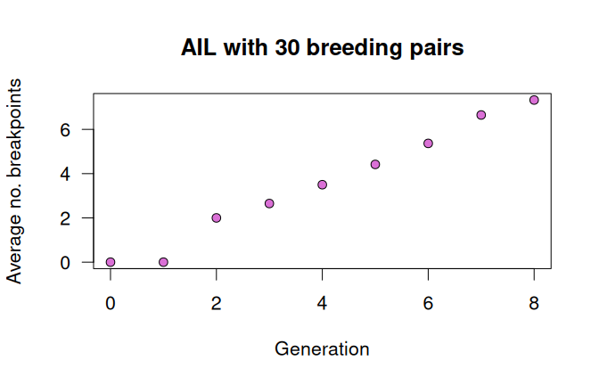

```r
n_breakpoints <- sapply(xodat, function(a) sum(sapply(a, function(b) length(b$alleles)-1)))
ave_breakpoints <- tapply(n_breakpoints, ailped$gen, mean)
gen <- as.numeric(names(ave_breakpoints))
plot(gen, ave_breakpoints,
     xlab="Generation", ylab="Average no. breakpoints", las=1,
     pch=21, bg="Orchid", main="AIL with 30 breeding pairs")
```

The function `where_het` will show the regions where an individual is heterozygous.

```r
where_het(xodat[[length(xodat)]])
```

```
##       left    right
## 1  0.00000 17.78088
## 2 19.20702 35.51860
## 3 43.17502 71.15012
```

We can plot the average proportion of the chromosome that is heterozygous, by generation, as follows.

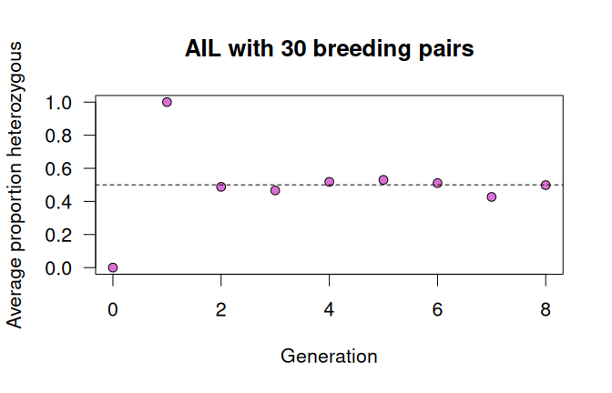

```r
prop_het <- sapply(lapply(xodat, where_het), function(a) sum(a[,2]-a[,1])/100)
ave_prop_het <- tapply(prop_het, ailped$gen, mean)
plot(gen, ave_prop_het,
     xlab="Generation", ylab="Average proportion heterozygous", las=1,
     pch=21, bg="Orchid", main="AIL with 30 breeding pairs")
abline(h=0.5, lty=2)
```

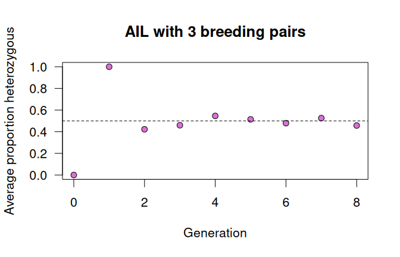

```r
ailped2 <- sim_ail_pedigree(ngen=8, npairs=3, nkids_per=50)
xodat2 <- sim_from_pedigree(ailped2, L=100)
prop_het2 <- sapply(lapply(xodat2, where_het), function(a) sum(a[,2]-a[,1])/100)
ave_prop_het2 <- tapply(prop_het2, ailped2$gen, mean)
gen2 <- as.numeric(names(ave_prop_het2))
plot(gen2, ave_prop_het2,
     xlab="Generation", ylab="Average proportion heterozygous", las=1,
     pch=21, bg="Orchid", main="AIL with 3 breeding pairs")
abline(h=0.5, lty=2)
```

## Generating marker data

R/simcross simulates the locations of crossovers as continuous values in the interval (0,L). This is precise and compact, and it allows detailed study of the breakpoint process, but it can be cumbersome to work with and is often not what you want from simulations. In most cases, one is interested in individuals’ genotypes at a set of markers.

There are two functions for getting marker genotypes on the basis of the the detailed crossover location data: `get_geno` and `convert2geno`.

The function `get_geno` will grab the genotype at a specified location on the chromosome, returning a matrix with two columns: the maternal and paternal alleles for each individual. Continuing with the simulation in the previous section (an AIL with 30 breeding pairs), here’s how to grab the genotype at 30 cM:

```r
g30 <- get_geno(xodat, 30)
tail(g30)
```

```
##     mat pat
## 509   1   2
## 510   1   1
## 511   1   1
## 512   1   2
## 513   1   2
## 514   1   2
```

The `get_geno` function could be useful, for example, for grabbing QTL genotypes for use in constructing a phenotype.

The `convert2geno` function takes the detailed crossover information plus a vector of marker locations and returns a matrix with marker genotypes.

First, construct a vector with the marker locations.

```r
map <- seq(0, 100, by=10)
names(map) <- paste0("m", map)
map
```

```
##   m0  m10  m20  m30  m40  m50  m60  m70  m80  m90 m100
##    0   10   20   30   40   50   60   70   80   90  100
```

Then, pass the crossover information and map to `convert2geno`. I print the data for the last five individuals.

```r
geno <- convert2geno(xodat, map)
geno[nrow(geno)-(4:0), ]
```

```
##     m0 m10 m20 m30 m40 m50 m60 m70 m80 m90 m100
## 510  1   2   2   1   1   2   2   2   2   2    2
## 511  2   3   2   1   1   2   2   1   2   2    2
## 512  2   1   2   2   1   2   2   3   2   2    2
## 513  2   2   2   2   1   2   2   3   3   3    3
## 514  2   2   2   2   1   2   2   2   3   3    3
```

Here the genotypes get recoded as `1` / `2` / `3` for `11` / `12` / `22`. That is, genotypes `1` and `3` are the homozygotes for the allele from founders 1 and 2, respectively, and genotype `2` is the heterozygote.

For crosses with more than two founders, the output of `convert2geno` is a three-dimensional array, individuals × markers × alleles (maternal and paternal). For example, here are genotypes for the sixth generations of inbreeding of an eight-way RIL.

```r
rilped <- sim_ril_pedigree(ngen=6, parents=1:8)
dat <- sim_from_pedigree(rilped, L=100)
geno <- convert2geno(dat, map)
geno[nrow(geno)-(1:0),,]
```

```
## , , mat
##
##    m0 m10 m20 m30 m40 m50 m60 m70 m80 m90 m100
## 27  7   5   5   5   5   3   3   3   3   3    7
## 28  7   5   5   5   5   3   3   5   5   6    7
##
## , , pat
##
##    m0 m10 m20 m30 m40 m50 m60 m70 m80 m90 m100
## 27  7   5   5   5   5   3   3   3   3   3    7
## 28  7   5   5   5   5   3   3   3   3   3    7
```

More commonly, one may be interested in individuals’ SNP genotypes. This can also be obtained with `convert2geno`; one just needs to provide a matrix of SNP alleles for the founder lines, with the argument `founder_geno`. This should be a matrix of `1`s and `2`s, of dimension `n_founders` × `n_markers`.

Let’s simulate SNP alleles for eight founder lines.

```r
fg <- matrix(sample(1:2, 8*length(map), replace=TRUE), nrow=8)
```

And then here are the SNP genotypes for the sixth generation of inbreeding an eight-way RIL.

```r
snpgeno <- convert2geno(dat, map, fg)
snpgeno[nrow(snpgeno)-(1:0),]
```

```
##    m0 m10 m20 m30 m40 m50 m60 m70 m80 m90 m100
## 27  3   3   1   1   1   3   3   3   3   1    3
## 28  3   3   1   1   1   3   3   2   2   1    3
```

The genotypes are again coded as `1` / `2` / `3` for `11` / `12` / `22`.

## Simulating multiple chromosomes

One can use `sim_from_pedigree` and `convert2geno` to simulate multiple chromosomes at once.

To simulate multiple chromosomes with `sim_from_pedigree`, provide a vector of chromosome lengths. In this case `xchr` should be either a logical vector, of the same length as `L`, or a character string with the name of the chromosome in `L` that correspond to the X chromosome.

```r
ailped3 <- sim_ail_pedigree(ngen=12, npairs=30, nkids_per=3)
xodat3 <- sim_from_pedigree(ailped3, c("1"=100, "2"=75, "X"=100), "X")
xodat3alt <- sim_from_pedigree(ailped3, c("1"=100, "2"=75, "X"=100),
                               c(FALSE, FALSE, TRUE))
```

To indicate that all chromosomes are autosomes, you can use `xchr=""`, `xchr=FALSE`, or `xchr=NULL`. For example:

```r
xodat3_noX <- sim_from_pedigree(ailped3, c("1"=100, "2"=75, "3"=100), "")
```

Having simulated multiple chromosomes with `sim_from_pedigree`, you may wish to use `convert2geno` to convert those results to marker genotypes. This is done by providing the output of `sim_from_pedigree` as well as a genetic marker map that is a *list* of vectors of marker locations.

Let’s first construct the marker map, assuming three chromosomes with lengths 100, 75, and 100.

```r
map <- list("1"=seq(0, 100, by=5),
            "2"=seq(0, 75, by=5),
            "X"=seq(0, 100, by=5))
for(i in seq(along=map))
    names(map[[i]]) <- paste0("m", names(map)[i], "_", map[[i]])
```

We then use `convert2geno`, ensuring that the inputs are both lists with the same length.

```r
geno <- convert2geno(xodat3, map)
```

For crosses like the DO, in which founder genotypes are needed, the input `founder_geno` must be a list of matrices (one matrix per chromosome).

Here are some simulated founder genotypes:

```r
fg <- vector("list", length(map))
for(i in seq(along=map))
    fg[[i]] <- matrix(sample(1:2, 8*length(map[[i]]), replace=TRUE), nrow=8)
```

And now here is the simulation of a small DO population for multiple chromosomes. When simulating the pedigree, we need to have 16 founders (the 8 female founders and then the 8 male founders). After simulating the genotypes with `sim_from_pedigree()`, we use `collapse_do_alleles()` to collapse the alleles 9-16 (for the male founders) into 1-8.

```r
doped <- sim_do_pedigree(ngen=4, nkids_per=1)
xodat <- sim_from_pedigree(doped, L=c("1"=100, "2"=75, "X"=100), "X")
xodat <- collapse_do_alleles(xodat)
geno <- convert2geno(xodat, map, fg)
```

## References

Broman KW (2012) [Genotype probabilities at intermediate generations in the construction of recombinant inbred lines](https://doi.org/10.1534/genetics.111.132647). Genetics 190:403-412 [doi: 10.1534/genetics.111.132647](https://doi.org/10.1534/genetics.111.132647)

Broman KW, Rowe LB, Churchill GA, Paigen K (2002) [Crossover interference in the mouse](https://doi.org/10.1093/genetics/160.3.1123). Genetics 160:1123-1131 [doi: 10.1093/genetics/160.3.1123](https://doi.org/10.1093/genetics/160.3.1123)

Copenhaver GP, Housworth EA, Stahl FW (2002) [Crossover interference in arabidopsis](https://doi.org/10.1093/genetics/160.4.1631). Genetics 160:1631-1639 [doi: 10.1093/genetics/160.4.1631](https://doi.org/10.1093/genetics/160.4.1631)

Foss E, Lande R, Stahl FW, Steinberg CM (1993) [Chiasma interference as a function of genetic distance](https://doi.org/10.1093/genetics/92.2.573). Genetics 133:681-691 [doi: 10.1093/genetics/92.2.573](https://doi.org/10.1093/genetics/92.2.573)

Kover PX, Valdar W, Trakalo J, Scarcelli N, Ehrenreich IM, Purugganan MD, Durrant C, Mott R (2009) [A Multiparent Advanced Generation Inter-Cross to fine-map quantitative traits in *Arabidopsis thaliana*](https://doi.org/10.1371/journal.pgen.1000551). PLoS Genetics 5:e1000551 [doi: 10.1371/journal.pgen.1000551](https://doi.org/10.1371/journal.pgen.1000551)

McPeek MS, Speed TP (1995) [Modeling interference in genetic recombination](https://doi.org/10.1093/genetics/139.2.1031). Genetics 139:1031-1044 [doi: 10.1093/genetics/139.2.1031](https://doi.org/10.1093/genetics/139.2.1031)

Mott R, Flint J (2002) [Simultaneous detection and fine mapping of quantitative trait loci in mice using heterogeneous stocks](https://doi.org/10.1093/genetics/160.4.1609). Genetics 160:1609-1618 [doi: 10.1093/genetics/160.4.1609](https://doi.org/10.1093/genetics/160.4.1609)

Svenson KL, Gatti DM, Valdar W, Welsh CE, Cheng R, Chesler EJ, Palmer AA, McMillan L, Churchill GA (2012) [High-resolution genetic mapping using the mouse Diversity Outbred population.](https://doi.org/10.1534/genetics.111.132597). Genetics 190:437-447 [doi: 10.1534/genetics.111.132597](https://doi.org/10.1534/genetics.111.132597)

Threadgill DW, Churchill GA (2012) [Ten years of the Collaborative Cross](https://doi.org/10.1534/genetics.111.138032). Genetics 190:291-294 [doi: 10.1534/genetics.111.138032](https://doi.org/10.1534/genetics.111.138032)

Zhao H, Speed TP, McPeek MS (1995) [Statistical analysis of crossover interference using the chi-square model](https://doi.org/10.1534/genetics.111.138032). Genetics 139:1045-1056 [doi: 10.1534/genetics.111.138032](https://doi.org/10.1534/genetics.111.138032)

[Karl Broman](https://kbroman.org/)